# Drew University (Madison, NJ)

### US student origins

First time degree seeking undergrads

| State | Number of students | Fraction of student body from each state | Fraction of 18 year olds from each state enrolled here |
| --- | --- | --- | --- |
| Alabama | 0 | 0 | 0 |
| Alaska | 0 | 0 | 0 |
| Arizona | 0 | 0 | 0 |
| Arkansas | 0 | 0 | 0 |
| California | 10 | 1/36 | 1/51526 |
| Colorado | 0 | 0 | 0 |
| Connecticut | 11 | 1/33 | 1/4567 |
| Delaware | 1 | 1/364 | 1/12574 |
| Florida | 1 | 1/364 | 1/242122 |
| Georgia | 1 | 1/364 | 1/142235 |
| Hawaii | 0 | 0 | 0 |
| Idaho | 0 | 0 | 0 |
| Illinois | 2 | 1/182 | 1/79860 |
| Indiana | 0 | 0 | 0 |
| Iowa | 0 | 0 | 0 |
| Kansas | 0 | 0 | 0 |
| Kentucky | 0 | 0 | 0 |
| Louisiana | 1 | 1/364 | 1/58016 |
| Maine | 3 | 1/121 | 1/5350 |
| Maryland | 8 | 1/46 | 1/9845 |
| Massachusetts | 8 | 1/46 | 1/12225 |
| Michigan | 0 | 0 | 0 |
| Minnesota | 0 | 0 | 0 |
| Mississippi | 0 | 0 | 0 |
| Missouri | 0 | 0 | 0 |
| Montana | 0 | 0 | 0 |
| Nebraska | 0 | 0 | 0 |
| Nevada | 0 | 0 | 0 |
| New Hampshire | 1 | 1/364 | 1/17322 |
| New Jersey | 262 | 1/1 | 1/417 |
| New Mexico | 0 | 0 | 0 |
| New York | 21 | 1/17 | 1/11667 |
| North Carolina | 1 | 1/364 | 1/141570 |
| North Dakota | 0 | 0 | 0 |
| Ohio | 1 | 1/364 | 1/151641 |
| Oklahoma | 0 | 0 | 0 |
| Oregon | 0 | 0 | 0 |
| Pennsylvania | 20 | 1/18 | 1/8329 |
| Rhode Island | 0 | 0 | 0 |
| South Carolina | 1 | 1/364 | 1/61666 |
| South Dakota | 0 | 0 | 0 |
| Tennessee | 1 | 1/364 | 1/83746 |
| Texas | 1 | 1/364 | 1/401311 |
| Utah | 1 | 1/364 | 1/49459 |
| Vermont | 2 | 1/182 | 1/4606 |
| Virginia | 3 | 1/121 | 1/36463 |
| Washington | 0 | 0 | 0 |
| West Virginia | 0 | 0 | 0 |
| Wisconsin | 3 | 1/121 | 1/25055 |
| Wyoming | 0 | 0 | 0 |

### Library resources

|  | Number | Number per undergrad |
| --- | --- | --- |
| Number of physical books | 641,836 | 375 |
| Number of physical media | 69,494 | 41 |
| Number of physical serials | 6,550 | 4 |
| Number of digital/electronic books | 279,468 | 164 |
| Number of digital/electronic databases | 207 | 207 |
| Number of digital/electronic media | 691 | 1 |
| Number of electronic serials | 138,582 | 81 |
| Total library collections (physical and electronic) | 1,136,828 | 665 |
| Total physical library circulations (books and media) | 8,916 | 6 |
| Total digital/electronic circulations (books and media) | 170,898 | 100 |
| Total library circulations (physical and digital/electronic) | 179,814 | 106 |
| Total interlibrary loans and documents provided to other libraries | 2,961 | 2 |
| Total interlibrary loans and documents received | 3,372 | 2 |

## Figures

### Student to faculty ratio compared to similar institutions:

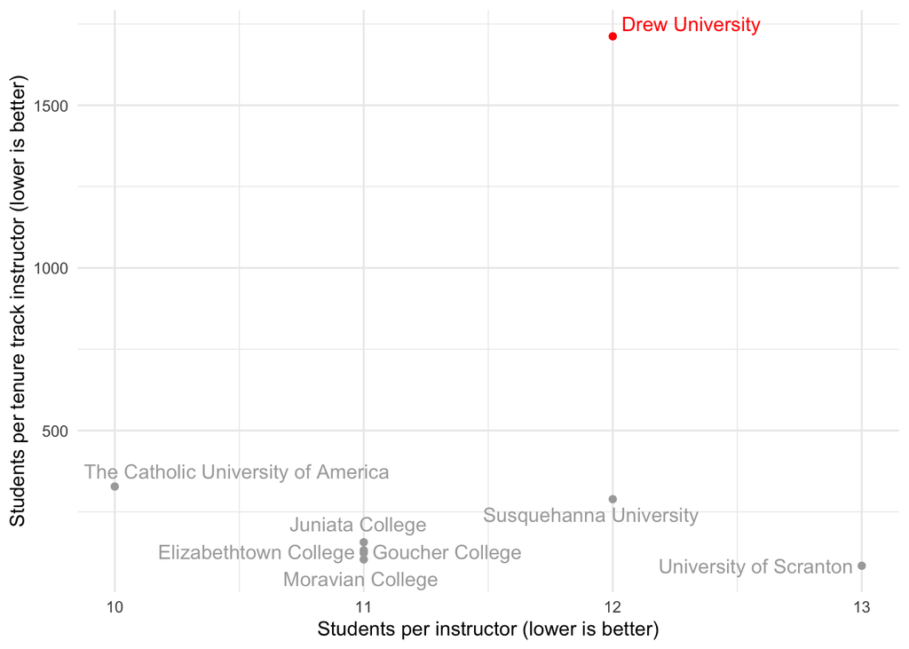

### Students from US

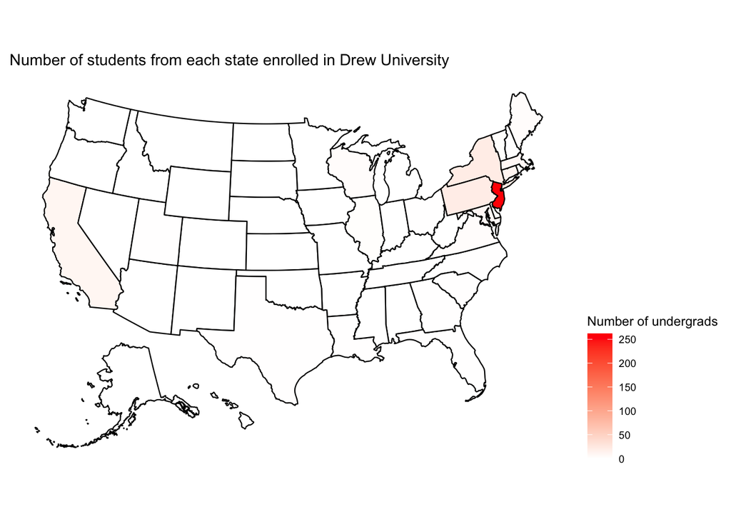

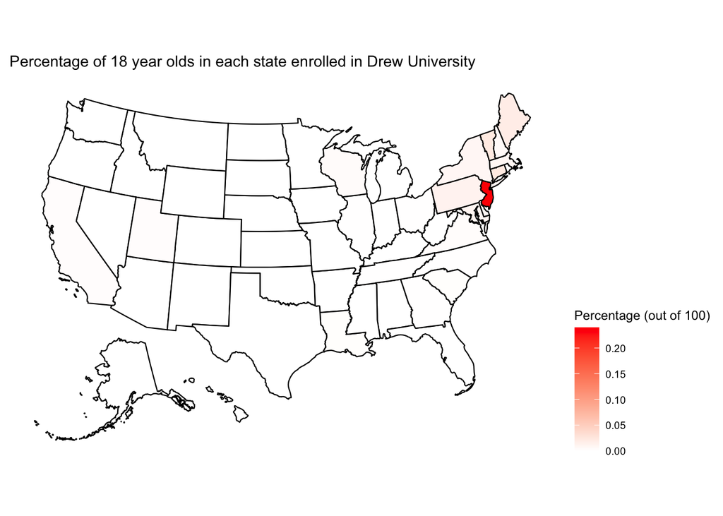